# Risk Factor Analysis

## Outcome Variable

**Outcome Variable:** ever_stunted

## Predictor Variables

**Intervention Variable:** cleanck

**Adjustment Set:**

- arm
- sex
- W_mage
- meducyrs
- feducyrs
- hhwealth_quart
- W_nrooms
- W_nhh
- W_nchldlt5
- W_parity
- trth2o
- impfloor
- delta_meducyrs
- delta_feducyrs
- delta_hhwealth_quart
- delta_W_nrooms
- delta_W_nhh
- delta_W_nchldlt5
- delta_W_parity
- delta_trth2o
- delta_impfloor

## Stratifying Variables

The analysis was stratified on these variable(s):

- agecat
- studyid
- country

## Data Summary

| agecat | studyid | country | cleanck | ever_stunted | n_cell | n |
| --- | --- | --- | --- | --- | --- | --- |
| 0-24 months (no birth st.) | CMC-V-BCS-2002 | INDIA | 1 | 0 | 21 | 296 |
| 0-24 months (no birth st.) | CMC-V-BCS-2002 | INDIA | 1 | 1 | 121 | 296 |
| 0-24 months (no birth st.) | CMC-V-BCS-2002 | INDIA | 0 | 0 | 7 | 296 |
| 0-24 months (no birth st.) | CMC-V-BCS-2002 | INDIA | 0 | 1 | 147 | 296 |
| 0-24 months (no birth st.) | GMS-Nepal | NEPAL | 1 | 0 | 8 | 517 |
| 0-24 months (no birth st.) | GMS-Nepal | NEPAL | 1 | 1 | 2 | 517 |
| 0-24 months (no birth st.) | GMS-Nepal | NEPAL | 0 | 0 | 215 | 517 |
| 0-24 months (no birth st.) | GMS-Nepal | NEPAL | 0 | 1 | 292 | 517 |
| 0-24 months (no birth st.) | IRC | INDIA | 1 | 0 | 94 | 352 |
| 0-24 months (no birth st.) | IRC | INDIA | 1 | 1 | 114 | 352 |
| 0-24 months (no birth st.) | IRC | INDIA | 0 | 0 | 49 | 352 |
| 0-24 months (no birth st.) | IRC | INDIA | 0 | 1 | 95 | 352 |
| 0-24 months (no birth st.) | MAL-ED | PERU | 1 | 0 | 1 | 2 |
| 0-24 months (no birth st.) | MAL-ED | PERU | 1 | 1 | 0 | 2 |
| 0-24 months (no birth st.) | MAL-ED | PERU | 0 | 0 | 0 | 2 |
| 0-24 months (no birth st.) | MAL-ED | PERU | 0 | 1 | 1 | 2 |
| 0-24 months (no birth st.) | MAL-ED | SOUTH AFRICA | 1 | 0 | 0 | 1 |
| 0-24 months (no birth st.) | MAL-ED | SOUTH AFRICA | 1 | 1 | 0 | 1 |
| 0-24 months (no birth st.) | MAL-ED | SOUTH AFRICA | 0 | 0 | 1 | 1 |
| 0-24 months (no birth st.) | MAL-ED | SOUTH AFRICA | 0 | 1 | 0 | 1 |
| 0-24 months (no birth st.) | NIH-Crypto | BANGLADESH | 1 | 0 | 199 | 498 |
| 0-24 months (no birth st.) | NIH-Crypto | BANGLADESH | 1 | 1 | 115 | 498 |
| 0-24 months (no birth st.) | NIH-Crypto | BANGLADESH | 0 | 0 | 119 | 498 |
| 0-24 months (no birth st.) | NIH-Crypto | BANGLADESH | 0 | 1 | 65 | 498 |
| 0-24 months (no birth st.) | PROVIDE | BANGLADESH | 1 | 0 | 340 | 633 |
| 0-24 months (no birth st.) | PROVIDE | BANGLADESH | 1 | 1 | 180 | 633 |
| 0-24 months (no birth st.) | PROVIDE | BANGLADESH | 0 | 0 | 55 | 633 |
| 0-24 months (no birth st.) | PROVIDE | BANGLADESH | 0 | 1 | 58 | 633 |
| 0-6 months (no birth st.) | CMC-V-BCS-2002 | INDIA | 1 | 0 | 96 | 292 |
| 0-6 months (no birth st.) | CMC-V-BCS-2002 | INDIA | 1 | 1 | 45 | 292 |
| 0-6 months (no birth st.) | CMC-V-BCS-2002 | INDIA | 0 | 0 | 84 | 292 |
| 0-6 months (no birth st.) | CMC-V-BCS-2002 | INDIA | 0 | 1 | 67 | 292 |
| 0-6 months (no birth st.) | GMS-Nepal | NEPAL | 1 | 0 | 10 | 517 |
| 0-6 months (no birth st.) | GMS-Nepal | NEPAL | 1 | 1 | 0 | 517 |
| 0-6 months (no birth st.) | GMS-Nepal | NEPAL | 0 | 0 | 416 | 517 |
| 0-6 months (no birth st.) | GMS-Nepal | NEPAL | 0 | 1 | 91 | 517 |
| 0-6 months (no birth st.) | IRC | INDIA | 1 | 0 | 143 | 352 |
| 0-6 months (no birth st.) | IRC | INDIA | 1 | 1 | 65 | 352 |
| 0-6 months (no birth st.) | IRC | INDIA | 0 | 0 | 87 | 352 |
| 0-6 months (no birth st.) | IRC | INDIA | 0 | 1 | 57 | 352 |
| 0-6 months (no birth st.) | MAL-ED | PERU | 1 | 0 | 1 | 2 |
| 0-6 months (no birth st.) | MAL-ED | PERU | 1 | 1 | 0 | 2 |
| 0-6 months (no birth st.) | MAL-ED | PERU | 0 | 0 | 0 | 2 |
| 0-6 months (no birth st.) | MAL-ED | PERU | 0 | 1 | 1 | 2 |
| 0-6 months (no birth st.) | MAL-ED | SOUTH AFRICA | 1 | 0 | 0 | 1 |
| 0-6 months (no birth st.) | MAL-ED | SOUTH AFRICA | 1 | 1 | 0 | 1 |
| 0-6 months (no birth st.) | MAL-ED | SOUTH AFRICA | 0 | 0 | 1 | 1 |
| 0-6 months (no birth st.) | MAL-ED | SOUTH AFRICA | 0 | 1 | 0 | 1 |
| 0-6 months (no birth st.) | NIH-Crypto | BANGLADESH | 1 | 0 | 262 | 498 |
| 0-6 months (no birth st.) | NIH-Crypto | BANGLADESH | 1 | 1 | 52 | 498 |
| 0-6 months (no birth st.) | NIH-Crypto | BANGLADESH | 0 | 0 | 150 | 498 |
| 0-6 months (no birth st.) | NIH-Crypto | BANGLADESH | 0 | 1 | 34 | 498 |
| 0-6 months (no birth st.) | PROVIDE | BANGLADESH | 1 | 0 | 446 | 633 |
| 0-6 months (no birth st.) | PROVIDE | BANGLADESH | 1 | 1 | 74 | 633 |
| 0-6 months (no birth st.) | PROVIDE | BANGLADESH | 0 | 0 | 86 | 633 |
| 0-6 months (no birth st.) | PROVIDE | BANGLADESH | 0 | 1 | 27 | 633 |

The following strata were considered:

- agecat: 0-24 months (no birth st.), studyid: CMC-V-BCS-2002, country: INDIA
- agecat: 0-24 months (no birth st.), studyid: GMS-Nepal, country: NEPAL
- agecat: 0-24 months (no birth st.), studyid: IRC, country: INDIA
- agecat: 0-24 months (no birth st.), studyid: MAL-ED, country: PERU
- agecat: 0-24 months (no birth st.), studyid: MAL-ED, country: SOUTH AFRICA
- agecat: 0-24 months (no birth st.), studyid: NIH-Crypto, country: BANGLADESH
- agecat: 0-24 months (no birth st.), studyid: PROVIDE, country: BANGLADESH
- agecat: 0-6 months (no birth st.), studyid: CMC-V-BCS-2002, country: INDIA
- agecat: 0-6 months (no birth st.), studyid: GMS-Nepal, country: NEPAL
- agecat: 0-6 months (no birth st.), studyid: IRC, country: INDIA
- agecat: 0-6 months (no birth st.), studyid: MAL-ED, country: PERU
- agecat: 0-6 months (no birth st.), studyid: MAL-ED, country: SOUTH AFRICA
- agecat: 0-6 months (no birth st.), studyid: NIH-Crypto, country: BANGLADESH
- agecat: 0-6 months (no birth st.), studyid: PROVIDE, country: BANGLADESH

### Dropped Strata

- agecat: 0-24 months (no birth st.), studyid: GMS-Nepal, country: NEPAL
- agecat: 0-24 months (no birth st.), studyid: MAL-ED, country: PERU
- agecat: 0-24 months (no birth st.), studyid: MAL-ED, country: SOUTH AFRICA
- agecat: 0-6 months (no birth st.), studyid: GMS-Nepal, country: NEPAL
- agecat: 0-6 months (no birth st.), studyid: MAL-ED, country: PERU
- agecat: 0-6 months (no birth st.), studyid: MAL-ED, country: SOUTH AFRICA

## Methods Detail

We're interested in the causal parameters $E[Y_a]$ for all values of $a \in \mathcal{A}$. These parameters represent the mean outcome if, possibly contrary to fact, we intervened to set all units to have $A=a$. Under the randomization and positivity assumptions, these are identified by the statistical parameters $\psi_a=E_W[E_{Y|A,W}(Y|A=a,W)]$. In addition, we're interested in the mean of $Y$, $E[Y]$ under no intervention (the observed mean). We will estimate these parameters by using SuperLearner to fit the relevant likelihood factors -- $E_{Y|A,W}(Y|A=a,W)$ and $p(A=a|W)$, and then updating our likelihood fit using a joint TMLE.

For unadjusted analyses ($W=\{\}$), initial likelihoods were estimated using Lrnr_glm to estimate the simple $E(Y|A)$ and Lrnr_mean to estimate $p(A)$. For adjusted analyses, a small library containing Lrnr_glmnet, Lrnr_xgboost, and Lrnr_mean was used.

Having estimated these parameters, we will then use the delta method to estimate relative risks and attributable risks relative to a prespecified baseline level of $A$.

# Results Detail

## Results Plots

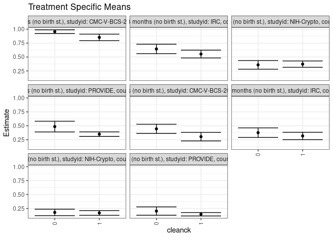

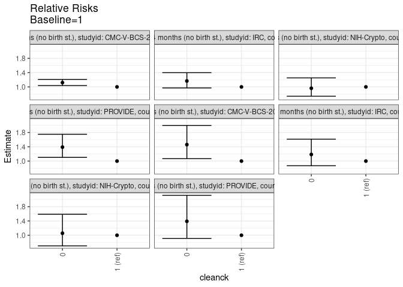

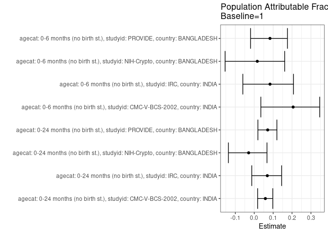

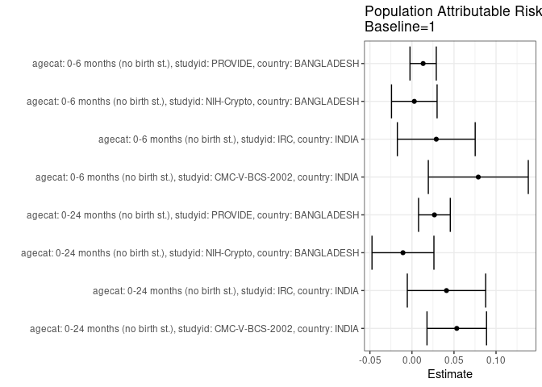

## Results Table

### Parameter: TSM

| agecat | studyid | country | intervention_level | baseline_level | estimate | ci_lower | ci_upper |
| --- | --- | --- | --- | --- | --- | --- | --- |
| 0-24 months (no birth st.) | CMC-V-BCS-2002 | INDIA | 1 | NA | 0.8521127 | 0.7936266 | 0.9105988 |
| 0-24 months (no birth st.) | CMC-V-BCS-2002 | INDIA | 0 | NA | 0.9545455 | 0.9215913 | 0.9874996 |
| 0-24 months (no birth st.) | IRC | INDIA | 1 | NA | 0.5526793 | 0.4824504 | 0.6229082 |
| 0-24 months (no birth st.) | IRC | INDIA | 0 | NA | 0.6443340 | 0.5593536 | 0.7293145 |
| 0-24 months (no birth st.) | NIH-Crypto | BANGLADESH | 1 | NA | 0.3721522 | 0.3156332 | 0.4286711 |
| 0-24 months (no birth st.) | NIH-Crypto | BANGLADESH | 0 | NA | 0.3581239 | 0.2806858 | 0.4355621 |
| 0-24 months (no birth st.) | PROVIDE | BANGLADESH | 1 | NA | 0.3492742 | 0.3082108 | 0.3903375 |
| 0-24 months (no birth st.) | PROVIDE | BANGLADESH | 0 | NA | 0.4854944 | 0.3892193 | 0.5817695 |
| 0-6 months (no birth st.) | CMC-V-BCS-2002 | INDIA | 1 | NA | 0.3046431 | 0.2276001 | 0.3816861 |
| 0-6 months (no birth st.) | CMC-V-BCS-2002 | INDIA | 0 | NA | 0.4448920 | 0.3622651 | 0.5275190 |
| 0-6 months (no birth st.) | IRC | INDIA | 1 | NA | 0.3176734 | 0.2513255 | 0.3840213 |
| 0-6 months (no birth st.) | IRC | INDIA | 0 | NA | 0.3764065 | 0.2903278 | 0.4624852 |
| 0-6 months (no birth st.) | NIH-Crypto | BANGLADESH | 1 | NA | 0.1699065 | 0.1274415 | 0.2123715 |
| 0-6 months (no birth st.) | NIH-Crypto | BANGLADESH | 0 | NA | 0.1794212 | 0.1214009 | 0.2374415 |
| 0-6 months (no birth st.) | PROVIDE | BANGLADESH | 1 | NA | 0.1462688 | 0.1154638 | 0.1770739 |
| 0-6 months (no birth st.) | PROVIDE | BANGLADESH | 0 | NA | 0.2033332 | 0.1288319 | 0.2778344 |

### Parameter: E(Y)

| agecat | studyid | country | intervention_level | baseline_level | estimate | ci_lower | ci_upper |
| --- | --- | --- | --- | --- | --- | --- | --- |
| 0-24 months (no birth st.) | CMC-V-BCS-2002 | INDIA | NA | NA | 0.9054054 | 0.8720096 | 0.9388012 |
| 0-24 months (no birth st.) | IRC | INDIA | NA | NA | 0.5937500 | 0.5423701 | 0.6451299 |
| 0-24 months (no birth st.) | NIH-Crypto | BANGLADESH | NA | NA | 0.3614458 | 0.3192090 | 0.4036825 |
| 0-24 months (no birth st.) | PROVIDE | BANGLADESH | NA | NA | 0.3759874 | 0.3382238 | 0.4137509 |
| 0-6 months (no birth st.) | CMC-V-BCS-2002 | INDIA | NA | NA | 0.3835616 | 0.3276935 | 0.4394298 |
| 0-6 months (no birth st.) | IRC | INDIA | NA | NA | 0.3465909 | 0.2968062 | 0.3963756 |
| 0-6 months (no birth st.) | NIH-Crypto | BANGLADESH | NA | NA | 0.1726908 | 0.1394601 | 0.2059214 |
| 0-6 months (no birth st.) | PROVIDE | BANGLADESH | NA | NA | 0.1595577 | 0.1310079 | 0.1881074 |

### Parameter: RR

| agecat | studyid | country | intervention_level | baseline_level | estimate | ci_lower | ci_upper |
| --- | --- | --- | --- | --- | --- | --- | --- |
| 0-24 months (no birth st.) | CMC-V-BCS-2002 | INDIA | 1 | 1 | 1.000000 | 1.0000000 | 1.000000 |
| 0-24 months (no birth st.) | CMC-V-BCS-2002 | INDIA | 0 | 1 | 1.120210 | 1.0373678 | 1.209669 |
| 0-24 months (no birth st.) | IRC | INDIA | 1 | 1 | 1.000000 | 1.0000000 | 1.000000 |
| 0-24 months (no birth st.) | IRC | INDIA | 0 | 1 | 1.165837 | 0.9713882 | 1.399210 |
| 0-24 months (no birth st.) | NIH-Crypto | BANGLADESH | 1 | 1 | 1.000000 | 1.0000000 | 1.000000 |
| 0-24 months (no birth st.) | NIH-Crypto | BANGLADESH | 0 | 1 | 0.962305 | 0.7396866 | 1.251923 |
| 0-24 months (no birth st.) | PROVIDE | BANGLADESH | 1 | 1 | 1.000000 | 1.0000000 | 1.000000 |
| 0-24 months (no birth st.) | PROVIDE | BANGLADESH | 0 | 1 | 1.390009 | 1.1036596 | 1.750654 |
| 0-6 months (no birth st.) | CMC-V-BCS-2002 | INDIA | 1 | 1 | 1.000000 | 1.0000000 | 1.000000 |
| 0-6 months (no birth st.) | CMC-V-BCS-2002 | INDIA | 0 | 1 | 1.460371 | 1.0674566 | 1.997912 |
| 0-6 months (no birth st.) | IRC | INDIA | 1 | 1 | 1.000000 | 1.0000000 | 1.000000 |
| 0-6 months (no birth st.) | IRC | INDIA | 0 | 1 | 1.184885 | 0.8697606 | 1.614183 |
| 0-6 months (no birth st.) | NIH-Crypto | BANGLADESH | 1 | 1 | 1.000000 | 1.0000000 | 1.000000 |
| 0-6 months (no birth st.) | NIH-Crypto | BANGLADESH | 0 | 1 | 1.055999 | 0.7024960 | 1.587390 |
| 0-6 months (no birth st.) | PROVIDE | BANGLADESH | 1 | 1 | 1.000000 | 1.0000000 | 1.000000 |
| 0-6 months (no birth st.) | PROVIDE | BANGLADESH | 0 | 1 | 1.390133 | 0.9125052 | 2.117763 |

### Parameter: PAR

| agecat | studyid | country | intervention_level | baseline_level | estimate | ci_lower | ci_upper |
| --- | --- | --- | --- | --- | --- | --- | --- |
| 0-24 months (no birth st.) | CMC-V-BCS-2002 | INDIA | 1 | NA | 0.0532927 | 0.0178815 | 0.0887039 |
| 0-24 months (no birth st.) | IRC | INDIA | 1 | NA | 0.0410707 | -0.0055459 | 0.0876873 |
| 0-24 months (no birth st.) | NIH-Crypto | BANGLADESH | 1 | NA | -0.0107064 | -0.0475403 | 0.0261276 |
| 0-24 months (no birth st.) | PROVIDE | BANGLADESH | 1 | NA | 0.0267132 | 0.0078338 | 0.0455926 |
| 0-6 months (no birth st.) | CMC-V-BCS-2002 | INDIA | 1 | NA | 0.0789186 | 0.0194582 | 0.1383789 |
| 0-6 months (no birth st.) | IRC | INDIA | 1 | NA | 0.0289175 | -0.0173826 | 0.0752176 |
| 0-6 months (no birth st.) | NIH-Crypto | BANGLADESH | 1 | NA | 0.0027843 | -0.0243265 | 0.0298950 |
| 0-6 months (no birth st.) | PROVIDE | BANGLADESH | 1 | NA | 0.0132888 | -0.0023512 | 0.0289288 |

### Parameter: PAF

| agecat | studyid | country | intervention_level | baseline_level | estimate | ci_lower | ci_upper |
| --- | --- | --- | --- | --- | --- | --- | --- |
| 0-24 months (no birth st.) | CMC-V-BCS-2002 | INDIA | 1 | NA | 0.0588606 | 0.0178699 | 0.0981405 |
| 0-24 months (no birth st.) | IRC | INDIA | 1 | NA | 0.0691717 | -0.0131559 | 0.1448095 |
| 0-24 months (no birth st.) | NIH-Crypto | BANGLADESH | 1 | NA | -0.0296210 | -0.1367410 | 0.0674046 |
| 0-24 months (no birth st.) | PROVIDE | BANGLADESH | 1 | NA | 0.0710481 | 0.0194270 | 0.1199517 |
| 0-6 months (no birth st.) | CMC-V-BCS-2002 | INDIA | 1 | NA | 0.2057519 | 0.0350009 | 0.3462895 |
| 0-6 months (no birth st.) | IRC | INDIA | 1 | NA | 0.0834342 | -0.0603385 | 0.2077126 |
| 0-6 months (no birth st.) | NIH-Crypto | BANGLADESH | 1 | NA | 0.0161228 | -0.1540489 | 0.1612017 |
| 0-6 months (no birth st.) | PROVIDE | BANGLADESH | 1 | NA | 0.0832853 | -0.0193695 | 0.1756024 |